# Assignment 1 CITS5508

### 4.4 Analysing the performance closer

So far, we have four logistic regression models:

- LR1: The model in 4.2, which is your implementation of the logistic regression without regulari- sation and with a fixed validation set;
- LR2: The model in 4.3, which is your implementation of the logistic regression with regularisation and with a fixed validation set;
- LR3: The the model in 4.3 using 10-fold cross-validation and the optimal value of the regularisa- tion hyperparameter C according to Grid Search but keeping the threshold value for the logistic regression prediction model at 0.5;
- LR4: The model in 4.3 using 10-fold cross-validation and the optimal value of the regularisation hyperparameter C according to Grid Search and threshold values according to your grid search in D13. We will give a closer investigation into the classification mistakes.

#### D14 [8 marks]:

Provide the model’s performance on the test set. For each LR1, LR2, LR3 and LR4, provide: • The confusion matrix; • Precision, recall, false positive rate.

```python
y_pred_proba_4 = model_LR4.predict_proba(X_val_scaled)[:, 1]
y_pred_4 = model_LR4.predict(X_val_scaled)
```

```python
# Function to calculate metrics
def model_performance(y_true, y_probs, threshold=0.5):
    # Convert probabilities to binary predictions
    y_pred = (y_probs >= threshold).astype(int)

    # Calculate the confusion matrix
    conf_matrix = confusion_matrix(y_true, y_pred)

    # Calculate precision and recall
    precision = precision_score(y_true, y_pred)
    recall = recall_score(y_true, y_pred)

    # Calculate the False Positive Rate (FPR)
    fpr = conf_matrix[0][1] / (conf_matrix[0][1] + conf_matrix[0][0])

    return {
        'Confusion Matrix': conf_matrix,
        'Precision': precision,
        'Recall': recall,
        'FPR': fpr
    }


performances = {
    'LR1': model_performance(y_val, y_pred_1),
    'LR2': model_performance(y_val, y_pred_2),
    'LR3': model_performance(y_val, y_pred_3),
    'LR4': model_performance(y_val, y_pred_4)
}

# Convert the performance metrics to a DataFrame for printing
df = pd.DataFrame.from_dict(performances, orient='index')
df = df[['Precision', 'Recall', 'FPR']]  # Reorder or select columns as needed
df
```

|  | Precision | Recall | FPR |
| --- | --- | --- | --- |
| LR1 | 0.892540 | 0.836106 | 0.101171 |
| LR2 | 0.968750 | 0.954243 | 0.030936 |
| LR3 | 0.945813 | 0.958403 | 0.055184 |
| LR4 | 0.950900 | 0.966722 | 0.050167 |

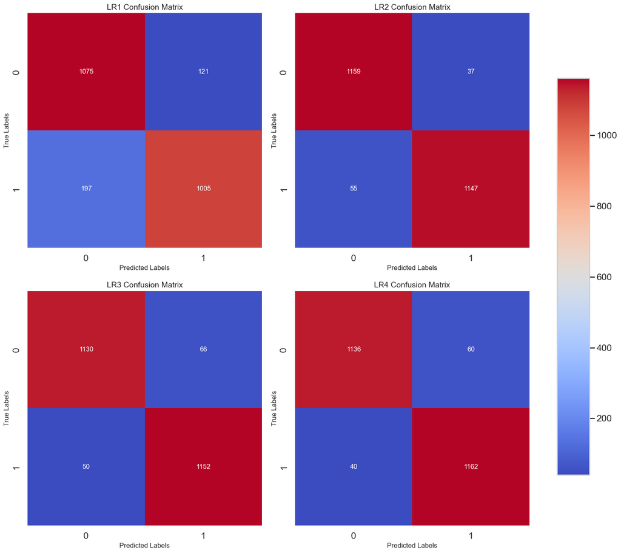

```python
fig, axes = plt.subplots(2, 2, figsize=(16, 14))

# Define a function to plot a styled heatmap to reduce code repetition
def plot_heatmap(data, ax, title):
    sns.heatmap(data, annot=True, fmt="d", cmap="coolwarm", ax=ax, cbar=False,
                annot_kws={"size": 12}, square=True)
    ax.set_xlabel('Predicted Labels', fontsize=12)
    ax.set_ylabel('True Labels', fontsize=12)
    ax.set_title(title, fontsize=14)

# Plot each confusion matrix with the new styling
plot_heatmap(performances['LR1'][0], axes[0, 0], 'LR1 Confusion Matrix')
plot_heatmap(performances['LR2'][0], axes[0, 1], 'LR2 Confusion Matrix')
plot_heatmap(performances['LR3'][0], axes[1, 0], 'LR3 Confusion Matrix')
plot_heatmap(performances['LR4'][0], axes[1, 1], 'LR4 Confusion Matrix')

# Adjust layout to fit properly
plt.tight_layout()

# Manually add a color bar to the last plot
fig.subplots_adjust(right=0.85)
cbar_ax = fig.add_axes([0.87, 0.15, 0.05, 0.7])  # Positioning the color bar
fig.colorbar(axes[1, 1].collections[0], cax=cbar_ax)

plt.show()
```

#### D15 [3 marks]:

Briefly comment on the results you see. Discuss the generalisation capacity of the four models.

#### D16 [4 marks]:

Consider the model LR4 and show five images that are false positives on the test set and five images that are false negatives.

```python
# Get the indices of false positives and false negatives
false_positives = np.where((y_pred_4 == 1) & (y_val == 0))[0]
false_negatives = np.where((y_pred_4 == 0) & (y_val == 1))[0]

# Select five of each for display
# Make sure there are at least five of each type, if not, display as many as available
fp_to_show = false_positives[:5] if len(false_positives) >= 5 else false_positives
fn_to_show = false_negatives[:5] if len(false_negatives) >= 5 else false_negatives
```

```python
# Predict the labels on the test set
y_pred_D16 = model_LR4.predict(X_val)

# Get the indices of false positives and false negatives
false_positives = np.where((y_pred_D16 == 1) & (y_val == 0))[0]
false_negatives = np.where((y_pred_D16 == 0) & (y_val == 1))[0]

# Select five of each for display
# Make sure there are at least five of each type, if not, display as many as available
fp_to_show = false_positives[:5] if len(false_positives) >= 5 else false_positives
fn_to_show = false_negatives[:5] if len(false_negatives) >= 5 else false_negatives
```

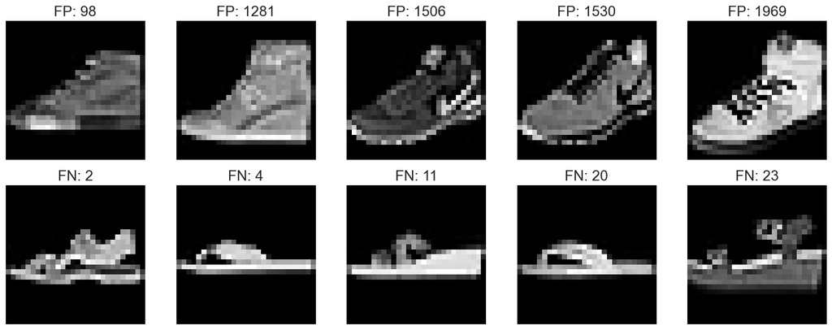

```python
# Plotting the false positives and false negatives images
fig, axs = plt.subplots(2, 5, figsize=(15, 6))  # Two rows (for FP and FN), five columns (for five images)

# Plot false positives
for i, idx in enumerate(fp_to_show):
    img = X_val.iloc[idx].values.reshape(28, 28)  # Reshape the flattened image data
    axs[0, i].imshow(img, cmap='gray')  # Plot the image
    axs[0, i].set_title(f"FP: {idx}")  # Set title with index
    axs[0, i].axis('off')  # Hide axes for clarity

# Plot false negatives
for i, idx in enumerate(fn_to_show):
    img = X_val.iloc[idx].values.reshape(28, 28)  # Reshape the flattened image data
    axs[1, i].imshow(img, cmap='gray')  # Plot the image
    axs[1, i].set_title(f"FN: {idx}")  # Set title with index
    axs[1, i].axis('off')  # Hide axes for clarity

plt.tight_layout()
plt.show()
```

#### D17 [2 marks]:

Briefly comment on the results. Can you describe what kinds of mistakes the model is making?

##### D17 Answer:

The model seems to struggle with shoes that have complex patterns or high contrast, possibly misinterpreting these features as indicative of the positive class and thus leading to false positives.

For false negatives, the issue appears to be the opposite: the model might be associating the lack of complexity or distinct features with the negative class, causing it to miss when such shoes actually belong to the positive class.

The mistakes could be due to overemphasis on certain features that are not as strongly indicative of class membership as the model assumes. This might be a result of the training data not having enough variety in the examples for the model to learn the true variability within each class.

#### D18 [2 marks]:

Let’s inspect the mistakes further and try to interpret the LR4’s estimated weights (parameters). Again, choose model LR4 and provide the model parameter values used for each image by reshaping them into a 28 x 28 matrix to associate the weights with the images. Plot the result using imshow(). You may need to adjust some values for the arguments in the function imshow() to better visualise the resulting image.

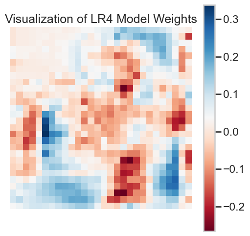

```python
# Extract the weights
weights = model_LR4.coef_[0]

# Reshape the weights into a 28x28 matrix
weights_matrix = weights.reshape(28, 28)

# Plotting the weights matrix
plt.figure(figsize=(6, 6))
plt.imshow(weights_matrix, cmap='RdBu', interpolation='nearest')
plt.colorbar()
plt.title("Visualization of LR4 Model Weights")
plt.axis('off')  # Hide axes for clarity
plt.show()
```

#### D19 [3 marks]:

Inspect the values and magnitude of the weights. Comment on what you think LR4 learned when distinguishing sandals and sneakers.

##### D19 Answer:

Areas with Neutral Weights (White or Light Colors): These regions seem to have little to no impact on the model's predictions. They are probably parts of the image that do not vary significantly between sandals and sneakers or do not provide useful information for distinguishing between the two.

The magnitude of the weights signifies the importance of that feature in making a classification decision. Larger absolute values (either positive or negative) indicate features that are highly influential in the model's predictions.

### 4.5 Comparing models

Use the k-nearest neighbours (k-NN) algorithm with the Euclidean distance for the same binary classifi- cation task. Try k values in the range [1, 30].

#### D20 [3 marks]:

Provide a plot showing the fraction of misclassifications (y-axis) for each k value (x- axis) for the training and validation set. Use the same validation set you created in section 4.2. That is, your plot should contain two results.

```python
# Try k values in the range [1, 30]
k_range = range(1, 31)
train_scores = []
test_scores = []

# Find the best k using cross-validation on the training set
for k in k_range:
    knn = KNeighborsClassifier(n_neighbors=k, metric='euclidean')
    # Cross-validation on the training set
    cv_scores = cross_val_score(knn, X_train_scaled, y_train, cv=5, scoring='accuracy')
    train_scores.append(cv_scores.mean())
    # Validation set score
    knn.fit(X_train_scaled, y_train)
    test_score = knn.score(X_val_scaled, y_val)
    test_scores.append(test_score)

# Determine the best k value for training and validation sets
best_k_train = k_range[np.argmax(train_scores)]
best_k_val = k_range[np.argmax(test_scores)]
```

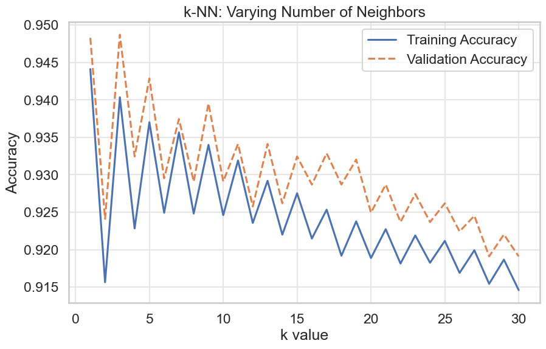

```python
# Plot accuracy vs k value for training and validation sets
plt.figure(figsize=(10, 6))
plt.plot(k_range, train_scores, label='Training Accuracy')
plt.plot(k_range, test_scores, label='Validation Accuracy', linestyle='--')
plt.xlabel('k value')
plt.ylabel('Accuracy')
plt.legend()
plt.title('k-NN: Varying Number of Neighbors')
plt.show()
```

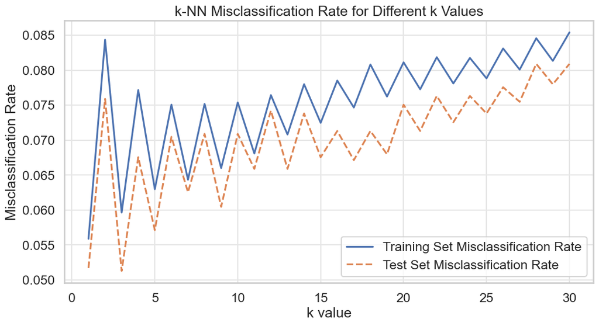

```python
# Convert the accuracy scores to misclassification rates
misclassification_rate_train = [1 - acc for acc in train_scores]
misclassification_rate_test = [1 - acc for acc in test_scores]

# Plot the misclassification rates
plt.figure(figsize=(12, 6))
plt.plot(k_range, misclassification_rate_train, label='Training Set Misclassification Rate')
plt.plot(k_range, misclassification_rate_test, label='Test Set Misclassification Rate', linestyle='--')
plt.xlabel('k value')
plt.ylabel('Misclassification Rate')
plt.title('k-NN Misclassification Rate for Different k Values')
plt.legend()
plt.grid(True)
plt.show()
```

#### D21 [4 marks]:

Comment on the results. What did you observe as the value of k increases? Which value of k would you choose and why? How does this model compare with the one you created in section 4.2?

##### D21 Answer:

- Training Set Misclassification Rate: Generally, as k increases, the training misclassification rate increases. This is expected because a larger k smooths the decision boundary by considering more neighbors, which reduces the model's sensitivity to the noise in the training data, and thus the model becomes less tailored to the training set.
- Test Set Misclassification Rate: The test misclassification rate shows a degree of volatility but generally trends upward as �k increases. Initially, increasing �k may help the model generalize better by reducing overfitting, which can lower the test misclassification rate. However, beyond a certain point, a larger �k may oversimplify the model, causing it to miss important nuances and leading to an increase in the test misclassification rate.

#### D22 [2 marks]:

Provide the k-NN performance on the test set for the k value you decided in task D21, providing:

- The confusion matrix;
- Precision, recall, false positive rate.

```python
# Train the kNN classifier with the best k value from the validation scores
knn_best = KNeighborsClassifier(n_neighbors=best_k_val, metric='euclidean')
knn_best.fit(X_train_scaled, y_train)

# Predictions for the test set
y_pred_knn = knn_best.predict(X_val_scaled)

# Confusion matrix
conf_matrix = confusion_matrix(y_val, y_pred_knn)

# Precision and Recall
precision = precision_score(y_val, y_pred_knn, average='binary')
recall = recall_score(y_val, y_pred_knn, average='binary')

# False Positive Rate (FPR)
fpr = conf_matrix[0][1] / float(conf_matrix[0][1] + conf_matrix[0][0])

print(f"Precision: {precision:.3f}")
print(f"Recall: {recall:.3f}")
print(f"False Positive Rate: {fpr:.3f}")
```

```
Precision: 0.992
Recall: 0.905
False Positive Rate: 0.008
```

```python
# Create a dictionary to hold the data
data = {
    "Precision": [f"{precision:.3f}"],
    "Recall": [f"{recall:.3f}"],
    "False Positive Rate": [f"{fpr:.3f}"]
}

# Convert the dictionary to a DataFrame
df = pd.DataFrame(data)

# Print the DataFrame
df
```

|  | Precision | Recall | False Positive Rate |
| --- | --- | --- | --- |
| 0 | 0.992 | 0.905 | 0.008 |

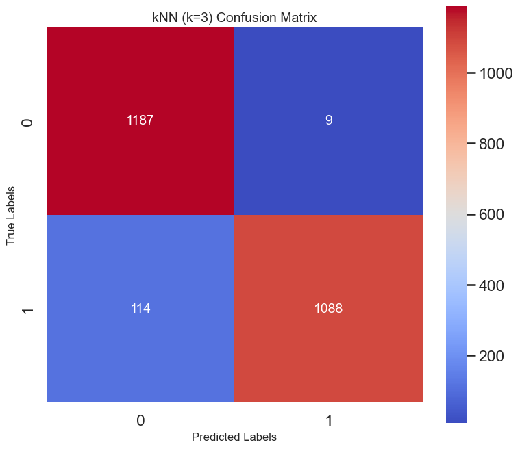

```python
fig, ax = plt.subplots(figsize=(8, 7))

# Plot a styled heatmap
sns.heatmap(conf_matrix, annot=True, fmt="d", cmap="coolwarm", ax=ax, cbar=True,
            annot_kws={"size": 14}, square=True)
ax.set_xlabel('Predicted Labels', fontsize=12)
ax.set_ylabel('True Labels', fontsize=12)
ax.set_title(f'kNN (k={best_k_val}) Confusion Matrix', fontsize=14)

# Adjust layout to fit properly
plt.tight_layout()
plt.show()
```

#### D23 [2 marks]:

Compare these performances with the logistic regression models (LR1, LR2, LR3 and LR4) obtained on deliverable D14. Briefly comment on the results you see, discussing the generalisation capacity of the different models.

##### D23 Answer:

- Precision: The k-NN model has the highest precision of all models, indicating that it has the highest probability of its positive predictions being correct. However, LR2 and LR4 also show high precision, with LR2 being particularly close to k-NN.
- Recall: The k-NN model has a lower recall compared to LR3 and LR4, which means it has a higher rate of false negatives. However, it has a higher recall than LR1.
- False Positive Rate: The k-NN model has a significantly lower FPR than all logistic regression models, which means it is least likely to falsely label negative instances as positive.

### 4.6 Exploring the ML pipeline

This last part of the assignment is open-ended and will assess your reflections on the machine learning pipeline. You are not restricted to the images’ 784-pixel values (features). Here, the idea is to think about different strategies you can use to improve the model’s performance.

We can investigate the relevant pixels for our binary classification, sandals and sneakers, and think of other information about them we could use in the classification.

#### D24 [5 marks]:

Comment on what you would do to improve the modelling.

##### D24 Answer:

Data Quality and Preprocessing:

- Increase Dataset Size: If feasible, collect more data to provide the model with more examples to learn from.
- Feature Scaling: Apply normalization or standardization to ensure all features contribute equally to the model's predictions.

Model Selection and Hyperparameter Tuning:

- Model Selection: Evaluate different models to find the best performer for your specific dataset, considering both simple models (to avoid overfitting) and more complex models (to capture more complex patterns).
- Hyperparameter Tuning: Use methods like grid search, random search, or Bayesian optimization to find the optimal hyperparameters for your model.
- Ensemble Methods: Combine multiple models to improve predictions. Techniques like bagging, boosting, and stacking can lead to better performance.

Evaluation and Validation:

- Cross-Validation: Use k-fold cross-validation to assess the model's performance more reliably and to ensure it generalizes well.
- Performance Metrics: Consider the problem's context to choose the right performance metrics, such as F1-score for imbalanced classes, ROC-AUC for binary classification, etc.

Experimentation and Iteration:

- Error Analysis: Review the model's mistakes to understand where it fails and why. This can inform further improvements in data preprocessing or feature engineering.
- Continuous Iteration: Modeling is an iterative process. Use insights from each round of modeling to refine your approach continuously.
- Experiment Tracking: Keep track of experiments with tools like MLflow or TensorBoard to systematically evaluate changes over time.

Advanced Techniques:

- Deep Learning: For certain types of data, such as images, deep learning models can capture complex patterns that traditional models cannot.
- Transfer Learning: Leverage pre-trained models on similar tasks to improve performance, especially when the dataset is not very large.
- Data Augmentation: In image, generate new training samples through various transformations to increase the robustness of the model.